# Statistical Learning, Deep Learning and A Complete Comparison

#### Reading the training data from csv file

```r
library(tidyverse)

disease_train <- read_csv("Disease Prediction Training(2).csv", col_types = cols())
attr(disease_train, 'spec') <- NULL
```

#### Size of the training dataset

```r
dim(disease_train)
```

```
## [1] 49000    12
```

```r
str(disease_train)
```

```
## Classes 'spec_tbl_df', 'tbl_df', 'tbl' and 'data.frame': 49000 obs. of  12 variables:
##  $ Age                : num  59 64 41 50 39 54 48 51 42 41 ...
##  $ Gender             : chr  "female" "female" "female" "male" ...
##  $ Height             : num  167 150 166 172 162 163 159 171 161 159 ...
##  $ Weight             : num  88 71 83 110 61 61 89 71 72 43 ...
##  $ High Blood Pressure: num  130 140 100 130 110 120 150 110 150 90 ...
##  $ Low Blood Pressure : num  68 100 70 80 80 80 90 70 90 60 ...
##  $ Cholesterol        : chr  "normal" "normal" "normal" "normal" ...
##  $ Glucose            : chr  "normal" "normal" "normal" "normal" ...
##  $ Smoke              : num  0 0 0 1 0 0 0 0 0 0 ...
##  $ Alcohol            : num  0 0 1 0 0 0 0 0 0 0 ...
##  $ Exercise           : num  1 0 1 1 1 1 1 1 1 1 ...
##  $ Disease            : num  0 1 0 0 0 0 1 0 1 0 ...
```

## Section 1: Data preparation

#### Valid column names

The column names have multiple wwords which are seperated by whitespace, which might be difficult to understand by some training methods. Hence, we convert them to vaild names.

```r
colnames(disease_train) <- make.names(colnames(disease_train))
```

#### Data quality issues

##### Missing values

```r
sum(!complete.cases(disease_train))
```

```
## [1] 0
```

There are no missing values in the dataset.

##### Data outliers

There are extreme outliers in High Blood Pressure, Low Blood Pressure these outliers can be winsorized.

The exterme outliers in Height and Weight on the lower end are practically not possible, these outlier can also be winsorized. The outliers towards the higher end in these columns can be posiible. So, we can retain them.

```r
winsorize <- function(x){
   qnt <- quantile(x, probs = c(.25, .75), na.rm = T)
   caps <- quantile(x, probs = c(.05, .95), na.rm = T)
   bound <- 1.5 * IQR(x, na.rm = T)
   if((x == disease_train$Height) | (x == disease_train$Weight)){
     x[x < (qnt[1] - bound)] <- caps[1]
   }
   else{
     x[x < (qnt[1] - bound)] <- caps[1]
     x[x > (qnt[2] + bound)] <- caps[2]
   }
   return(x)
}

disease_train$High.Blood.Pressure <- winsorize(disease_train$High.Blood.Pressure)
disease_train$Low.Blood.Pressure <- winsorize(disease_train$Low.Blood.Pressure)
disease_train$Height <- winsorize(disease_train$Height)
disease_train$Weight <- winsorize(disease_train$Weight)
```

The values less than Q1 - 1.5(IQR) are winsorized to 5th percentile and the values greater than Q3 + 1.5(IQR) are winsorized to 95th percentile.

##### Erroneous data

```r
nrow(disease_train[disease_train$High.Blood.Pressure < disease_train$Low.Blood.Pressure,])
```

```
## [1] 28
```

There are some observations in which High Blood Pressure is lower than Low Blood Pressure which is not possible. In such cases we can swap the values.

```r
index <- which(disease_train$High.Blood.Pressure < disease_train$Low.Blood.Pressure)
for(i in index){
  x <- disease_train[i, "High.Blood.Pressure"]
  disease_train[i, "High.Blood.Pressure"] <- disease_train[i, "Low.Blood.Pressure"]
  disease_train[i, "Low.Blood.Pressure"] <- x
}
```

##### Duplicate data

```r
nrow(disease_train[duplicated(disease_train), ])
```

```
## [1] 1798
```

Removing the 1798 duplicate observations from the dataframe.

```r
disease_train <- disease_train[!duplicated(disease_train), ]
```

#### Factorizing traget variable

Most of the machine learning algorithms require target variable to be factors in order to work efficiently.

```r
disease_train$Disease <- as.factor(disease_train$Disease)
```

#### Training and validation datasets

Since we require validation dataset to determine the performance of the model, we split the train dataset into training and validation data. Test data: 80% Validation data: 20%

```r
library(caret)

set.seed(188)
train_index <- createDataPartition(disease_train$Disease, p = 0.8, list = FALSE)
strain1 <- disease_train[train_index, ]
sval1 <- disease_train[-train_index, ]
```

#### Numerization and standardization using recipes

ANNs perform faster when features are standardized. We are performing all required numerization(onehot encoding) and standardization(scaling and mormalizing) using the ‘recipies’ package.

```r
library(recipes)

rec_obj <- recipe(Disease ~ ., data = strain1) %>%
  step_dummy(all_nominal(), -all_outcomes()) %>%
  step_center(all_predictors(), -all_outcomes()) %>%
  step_scale(all_predictors(), -all_outcomes()) %>%
  prep(data = strain1)
```

Applying the above recipe on training and validation data to convert it to dataset required for ANN.

```r
x_strain2 <- bake(rec_obj, new_data = strain1) %>% select(-Disease)
x_sval2  <- bake(rec_obj, new_data = sval1) %>% select(-Disease)
```

Storing the target variable as a vector whihc is needed for modeling ANN.

```r
y_strain2 <- ifelse(pull(strain1, Disease) == 1, 1, 0)
y_sval2  <- ifelse(pull(sval1, Disease) == 1, 1, 0)
```

#### Exploratory data analysis

##### How many patients have cardiac disease?

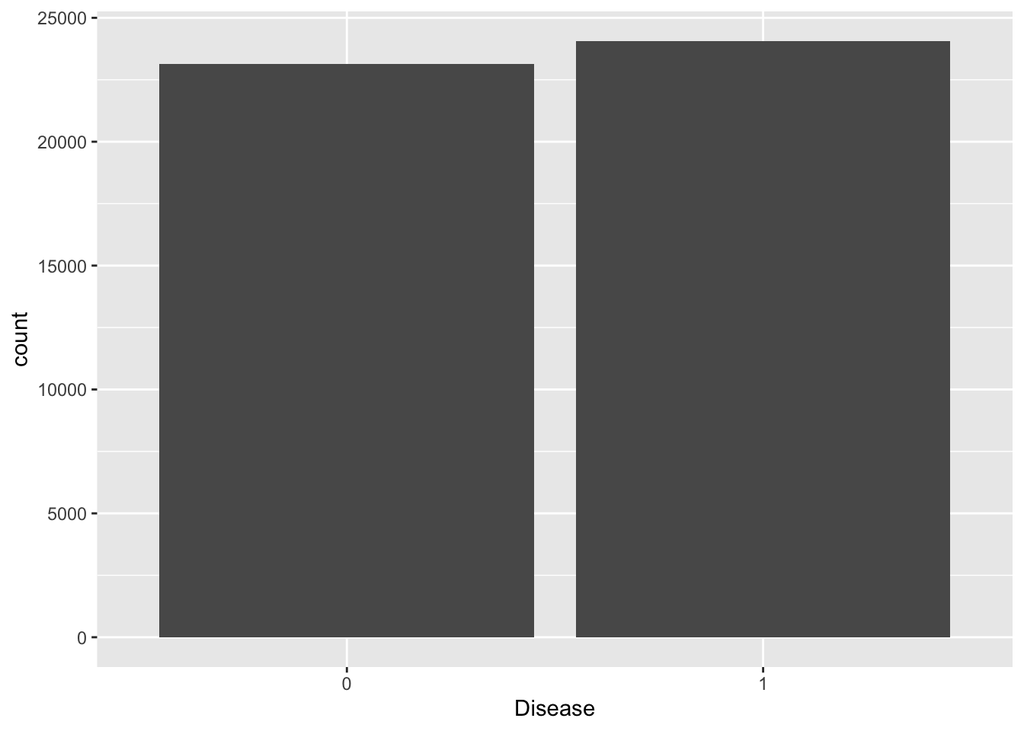

```r
library(ggplot2)

ggplot(disease_train) +
  geom_bar(aes(x = Disease))
```

##### What proportion of male and female patients have cardiac disease?

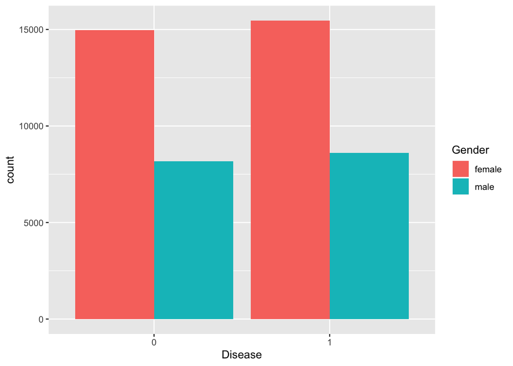

```r
ggplot(disease_train, aes(x = Disease, fill = Gender)) +
  geom_bar(position = "dodge")
```

##### How does high blood pressure affect disease?

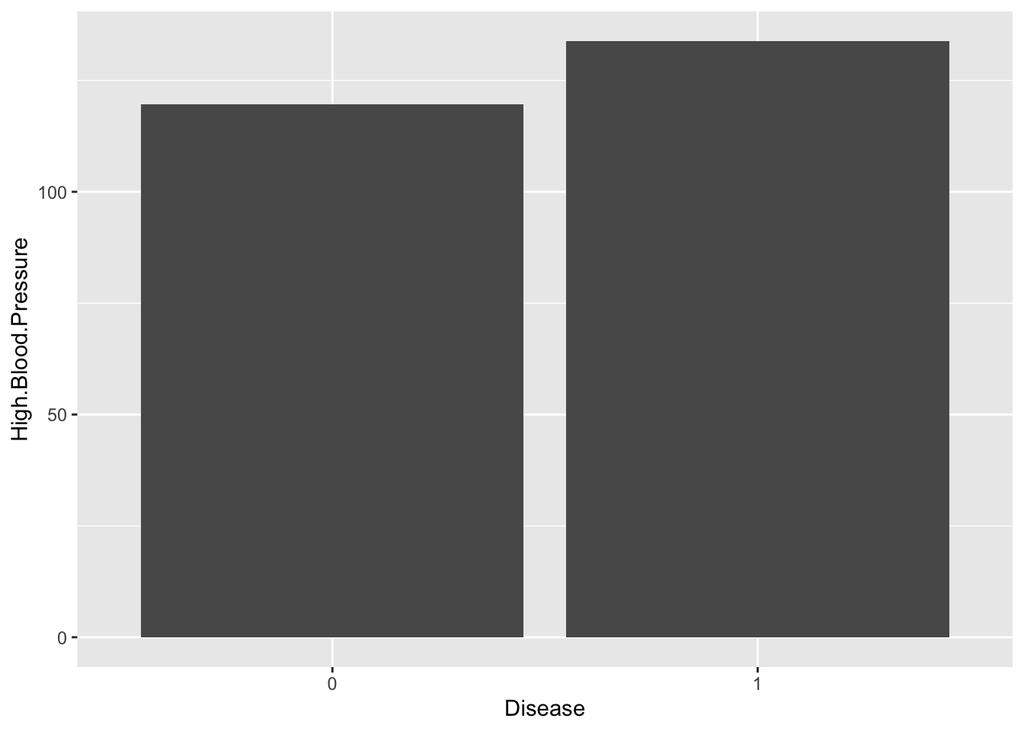

```r
ggplot(disease_train, aes(x = Disease, y = High.Blood.Pressure)) +
  stat_summary(fun.y = "mean", geom = "bar")
```

People with average high blood pressure greater than 125 tend to have the disease.

##### Is disease affected by cholesterol?

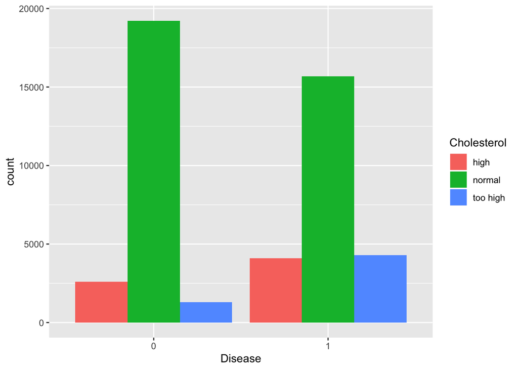

```r
ggplot(disease_train, aes(x = Disease, fill = Cholesterol)) +
  geom_bar(position = "dodge")
```

People with cholesterol above normal usually tend to have the disease.

## Section 2: Build, tune and evaluate various machine learning algorithms

#### Logistic Regression

Logistic regression model is built using the glm method in caret package with 3 fold cross validation.

glm method doesn’t have any tuning parameter.

```r
start_time <- Sys.time()

lr_model <- train(Disease ~ ., data = strain1,
                  method = "glm", family = "binomial",
                  trControl = trainControl(method = "cv", number = 3))

lr_time <- Sys.time() - start_time

lr_model
```

```
## Generalized Linear Model
##
## 37762 samples
##    11 predictor
##     2 classes: '0', '1'
##
## No pre-processing
## Resampling: Cross-Validated (3 fold)
## Summary of sample sizes: 25175, 25174, 25175
## Resampling results:
##
##   Accuracy   Kappa
##   0.7273185  0.4554137
```

```r
lr_time
```

```
## Time difference of 1.656445 secs
```

##### Performance evaluation of Logistic Regression

Evaluating the performance of logistic regression model using hold out method by creating confusion matrix and determining its accuracy.

```r
predict_lr <- predict(lr_model, newdata = sval1)
confusionMatrix(predict_lr, sval1$Disease)
```

```
## Confusion Matrix and Statistics
##
##           Reference
## Prediction    0    1
##          0 3556 1462
##          1 1071 3351
##
##                Accuracy : 0.7317
##                  95% CI : (0.7226, 0.7406)
##     No Information Rate : 0.5099
##     P-Value [Acc > NIR] : < 2.2e-16
##
##                   Kappa : 0.464
##
##  Mcnemar's Test P-Value : 9.26e-15
##
##             Sensitivity : 0.7685
##             Specificity : 0.6962
##          Pos Pred Value : 0.7086
##          Neg Pred Value : 0.7578
##              Prevalence : 0.4901
##          Detection Rate : 0.3767
##    Detection Prevalence : 0.5316
##       Balanced Accuracy : 0.7324
##
##        'Positive' Class : 0
##
```

##### ROC curve for Logestic Regression

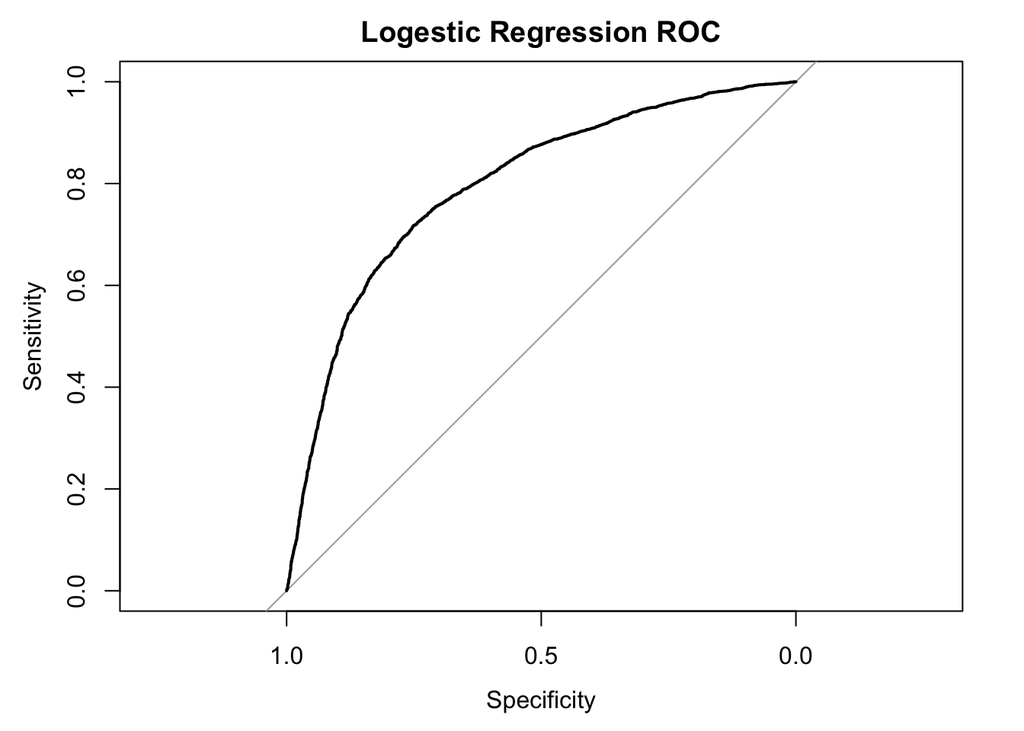

```r
library(pROC)

lr_pred_prob <- predict(lr_model, newdata = sval1, type = "prob")
lr_roc <- roc(sval1$Disease, lr_pred_prob$'1', print.auc = TRUE)
plot(lr_roc, main = "Logestic Regression ROC")
```

##### AUC score for Logestic Regression

```r
auc(lr_roc)
```

```
## Area under the curve: 0.795
```

#### Decision Tree

```r
library(caret)
library(rpart)

start_time <- Sys.time()

dt_model <- train(Disease ~ ., data = strain1, metric = "Accuracy", method = "rpart",
                  trControl = trainControl(method = "cv", number = 3),
                  tuneLength = 8,
                  control = rpart.control(minsplit = 40, minbucket = 10, maxdepth = 30))

dt_time <- Sys.time() - start_time

dt_model
```

```
## CART
##
## 37762 samples
##    11 predictor
##     2 classes: '0', '1'
##
## No pre-processing
## Resampling: Cross-Validated (3 fold)
## Summary of sample sizes: 25175, 25175, 25174
## Resampling results across tuning parameters:
##
##   cp           Accuracy   Kappa
##   0.001080614  0.7282983  0.4569855
##   0.001107629  0.7282983  0.4569855
##   0.001242706  0.7281658  0.4568437
##   0.002053166  0.7268947  0.4540892
##   0.003511995  0.7248291  0.4499604
##   0.004754701  0.7229225  0.4468708
##   0.010157770  0.7185264  0.4383858
##   0.413118651  0.5763748  0.1401565
##
## Accuracy was used to select the optimal model using the largest value.
## The final value used for the model was cp = 0.001107629.
```

```r
dt_time
```

```
## Time difference of 3.492092 secs
```

##### Performance evaluation of Decision Tree

Performance of decision tree can be evaluated using confusion matrix.

```r
predict_dt <- predict(dt_model, newdata = sval1)
confusionMatrix(predict_dt, sval1$Disease)
```

```
## Confusion Matrix and Statistics
##
##           Reference
## Prediction    0    1
##          0 3386 1311
##          1 1241 3502
##
##                Accuracy : 0.7297
##                  95% CI : (0.7206, 0.7386)
##     No Information Rate : 0.5099
##     P-Value [Acc > NIR] : <2e-16
##
##                   Kappa : 0.4593
##
##  Mcnemar's Test P-Value : 0.172
##
##             Sensitivity : 0.7318
##             Specificity : 0.7276
##          Pos Pred Value : 0.7209
##          Neg Pred Value : 0.7384
##              Prevalence : 0.4901
##          Detection Rate : 0.3587
##    Detection Prevalence : 0.4976
##       Balanced Accuracy : 0.7297
##
##        'Positive' Class : 0
##
```

The model has an accuracy of 73% on the validation dataset.

##### ROC curve for Decision Tree

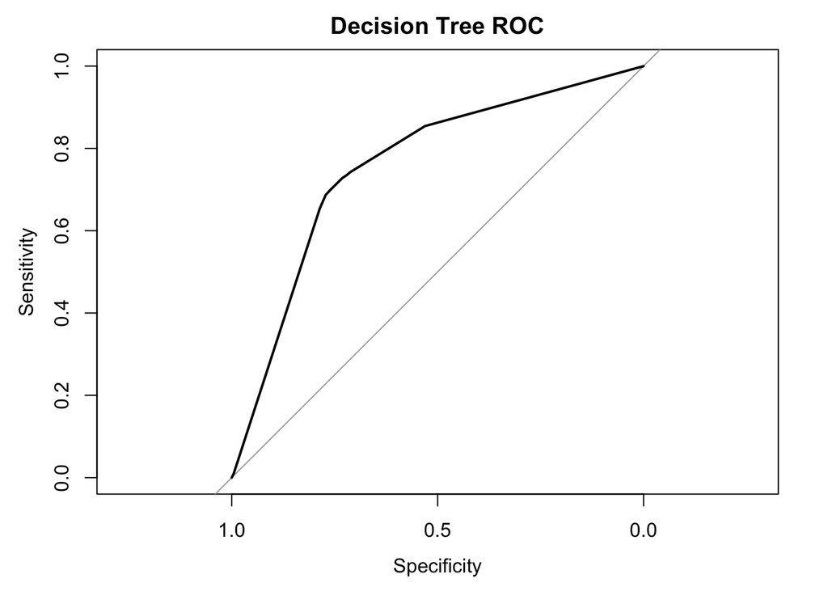

```r
dt_pred_prob <- predict(dt_model, newdata = sval1, type = "prob")
dt_roc <- roc(sval1$Disease, dt_pred_prob$'1', print.auc = TRUE)
plot(dt_roc, main = "Decision Tree ROC")
```

##### AUC score for Decision Tree

```r
auc(dt_roc)
```

```
## Area under the curve: 0.7587
```

#### Artificial Neural Network

Using Multi-Layer Perceptron (MLP) as they are good at classification. The hidden layers and output layers are what controls the ANN inner workings. Since it is a binary classification problem, we have only one node in the output layer. The output layer uses sigmoid activation function and log loss function since there are only two output classes.

##### ANN0

For ANN with zero hidden layers the input layer is directly connected to the output layer. . It uses adam optimization algorithm.

```r
library(keras)
library(tensorflow)

keras_model0 <- keras_model_sequential()

keras_model0 %>%
  layer_dense(units = 1,
              kernel_initializer = "uniform",
              activation = "sigmoid",
              input_shape = ncol(x_strain2)) %>%
  compile(optimizer = "adam",
          loss = "binary_crossentropy",
          metrics = c("accuracy"))

keras_model0
```

```
## Model
## Model: "sequential"
## ________________________________________________________________________________
## Layer (type)                        Output Shape                    Param #
## ================================================================================
## dense (Dense)                       (None, 1)                       14
## ================================================================================
## Total params: 14
## Trainable params: 14
## Non-trainable params: 0
## ________________________________________________________________________________
```

Running ANN0 on training data with 60 samples per gradient update within each epoch and 75 training cycles. We set validation_split = 0.2 to include 20% of the data for model validation, which prevents overfitting.

```r
start_time <- Sys.time()

ann0_model <- fit(object = keras_model0,
                  x = as.matrix(x_strain2),
                  y = y_strain2,
                  batch_size = 60,
                  epochs = 75,
                  validation_split = 0.2)

ann0_time <- Sys.time() - start_time
```

Inspecting the training history for ANN0.

```r
ann0_model
```

```
## Trained on 30,209 samples (batch_size=60, epochs=75)
## Final epoch (plot to see history):
##         loss: 0.5567
##     accuracy: 0.7281
##     val_loss: 0.5566
## val_accuracy: 0.7253
```

```r
ann0_time
```

```
## Time difference of 43.84866 secs
```

There’s very small difference training and validation accuracy.

Visualizing the training results for ANN0.

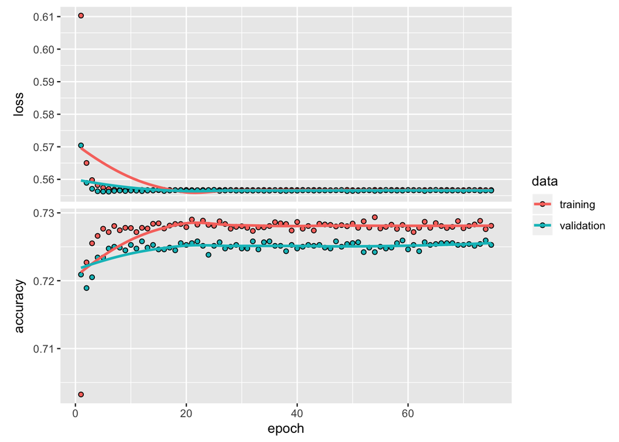

```r
plot(ann0_model)
```

###### Predictions of ANN0

Predicting the output class and class probability of validation data using ANN0.

```r
library(yardstick)

#predicted class
yhat_keras_class_vec <- predict_classes(object = keras_model0, x = as.matrix(x_sval2)) %>%
  as.vector()

#pedicted class probability
yhat_keras_prob_vec  <- predict_proba(object = keras_model0, x = as.matrix(x_sval2)) %>%
    as.vector()
```

Creating a data frame with actual value, estimated value and probability of the validation data.

```r
estimates_ann0 <- tibble(truth = as.factor(y_sval2),
                              estimate = as.factor(yhat_keras_class_vec),
                              class_prob = yhat_keras_prob_vec)

options(yardstick.event_first = FALSE)
```

Obtaining confusion table for validation data to examine the performance.

```r
estimates_ann0 %>% conf_mat(truth, estimate)
```

```
##           Truth
## Prediction    0    1
##          0 3580 1484
##          1 1047 3329
```

Determining accuracy of validation dataset.

```r
estimates_ann0 %>% metrics(truth, estimate)
```

```
## # A tibble: 2 x 3
##   .metric  .estimator .estimate
##   <chr>    <chr>          <dbl>
## 1 accuracy binary         0.732
## 2 kap      binary         0.465
```

ANN0 correctly predicts the class 73% of the time.

AUC score of ANN0.

```r
estimates_ann0 %>% roc_auc(truth, class_prob)
```

```
## # A tibble: 1 x 3
##   .metric .estimator .estimate
##   <chr>   <chr>          <dbl>
## 1 roc_auc binary         0.795
```

##### ANN1

In case of ANN with one hidden layer, the input layer is connected to the first hidden layer which has 50 nodes and uses relu activation function. Dropout layer is used to control overfitting which eliminates weights below 0.1 for the first hidden layer.

```r
keras_model1 <- keras_model_sequential()

keras_model1 %>%
  layer_dense(units = 50,
              kernel_initializer = "uniform",
              activation = "relu",
              input_shape = ncol(x_strain2)) %>%
  layer_dropout(rate = 0.1) %>%
  layer_dense(units = 1,
              kernel_initializer = "uniform",
              activation = "sigmoid") %>%
  compile(optimizer = "adam",
          loss = "binary_crossentropy",
          metrics = c("accuracy"))

keras_model1
```

```
## Model
## Model: "sequential_1"
## ________________________________________________________________________________
## Layer (type)                        Output Shape                    Param #
## ================================================================================
## dense_1 (Dense)                     (None, 50)                      700
## ________________________________________________________________________________
## dropout (Dropout)                   (None, 50)                      0
## ________________________________________________________________________________
## dense_2 (Dense)                     (None, 1)                       51
## ================================================================================
## Total params: 751
## Trainable params: 751
## Non-trainable params: 0
## ________________________________________________________________________________
```

Running ANN1 on training data with 50 samples per gradient update within each epoch and 75 training cycles. We set validation_split = 0.2 to include 20% of the data for model validation, which prevents overfitting.

```r
start_time <- Sys.time()

ann1_model <- fit(object = keras_model1,
                  x = as.matrix(x_strain2),
                  y = y_strain2,
                  batch_size = 50,
                  epochs = 75,
                  validation_split = 0.2)

ann1_time <- Sys.time() - start_time
```

Inspecting the training history for ANN1.

```r
ann1_model
```

```
## Trained on 30,209 samples (batch_size=50, epochs=75)
## Final epoch (plot to see history):
##         loss: 0.542
##     accuracy: 0.735
##     val_loss: 0.5444
## val_accuracy: 0.7306
```

```r
ann1_time
```

```
## Time difference of 1.014112 mins
```

Both training and validation data have almost the same loss and accuracy values.

Visualizing training results for ANN1.

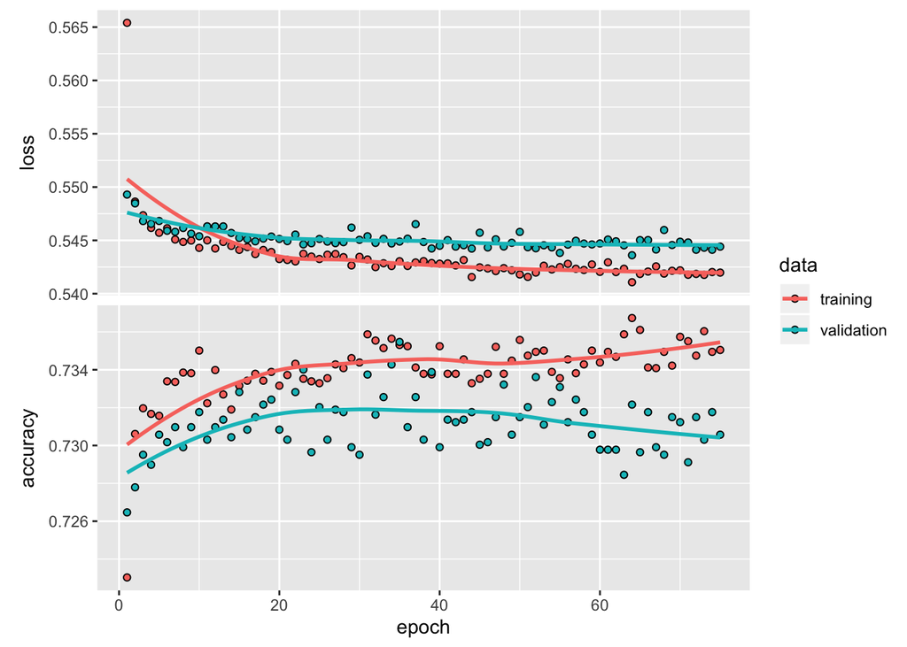

```r
plot(ann1_model)
```

###### Predictions of ANN1

Predicting the output class and class probability of validation data using ANN1.

```r
#predicted class
yhat_keras_class_vec <- predict_classes(object = keras_model1, x = as.matrix(x_sval2)) %>%
  as.vector()

#predicted class probability
yhat_keras_prob_vec  <- predict_proba(object = keras_model1, x = as.matrix(x_sval2)) %>%
    as.vector()
```

Creating a data frame with actual value, estimated value and probability of the validation data.

```r
estimates_ann1 <- tibble(truth = as.factor(y_sval2),
                              estimate = as.factor(yhat_keras_class_vec),
                              class_prob = yhat_keras_prob_vec)

options(yardstick.event_first = FALSE)
```

Obtaining confusion table for validation data to examine the performance.

```r
estimates_ann1 %>% conf_mat(truth, estimate)
```

```
##           Truth
## Prediction    0    1
##          0 3446 1319
##          1 1181 3494
```

Determining accuracy of validation dataset.

```r
estimates_ann1 %>% metrics(truth, estimate)
```

```
## # A tibble: 2 x 3
##   .metric  .estimator .estimate
##   <chr>    <chr>          <dbl>
## 1 accuracy binary         0.735
## 2 kap      binary         0.470
```

ANN1 correctly predicts the class 73% of the time.

AUC score of ANN1.

```r
estimates_ann1 %>% roc_auc(truth, class_prob)
```

```
## # A tibble: 1 x 3
##   .metric .estimator .estimate
##   <chr>   <chr>          <dbl>
## 1 roc_auc binary         0.803
```

##### ANN2

For ANN with two hidden layers, the inupt is fed to the first hidden layer. The first layer has 50 nodes and uses the sigmoid activation function. The second hidden layer uses tanh activation function and has 35 nodes. Both the layers have a dropout rate of 0.1.

```r
keras_model2 <- keras_model_sequential()

keras_model2 %>%
  layer_dense(units = 50,
              kernel_initializer = "uniform",
              activation = "sigmoid",
              input_shape = ncol(x_strain2)) %>%
  layer_dropout(rate = 0.1) %>%
  layer_dense(units = 35,
              kernel_initializer = "uniform",
              activation = "tanh") %>%
  layer_dropout(rate = 0.1) %>%
  layer_dense(units = 1,
              kernel_initializer = "uniform",
              activation = "sigmoid") %>%
  compile(optimizer = "adam",
          loss = "binary_crossentropy",
          metrics = c("accuracy"))

keras_model2
```

```
## Model
## Model: "sequential_2"
## ________________________________________________________________________________
## Layer (type)                        Output Shape                    Param #
## ================================================================================
## dense_3 (Dense)                     (None, 50)                      700
## ________________________________________________________________________________
## dropout_1 (Dropout)                 (None, 50)                      0
## ________________________________________________________________________________
## dense_4 (Dense)                     (None, 35)                      1785
## ________________________________________________________________________________
## dropout_2 (Dropout)                 (None, 35)                      0
## ________________________________________________________________________________
## dense_5 (Dense)                     (None, 1)                       36
## ================================================================================
## Total params: 2,521
## Trainable params: 2,521
## Non-trainable params: 0
## ________________________________________________________________________________
```

Running ANN2 on training data with 50 samples per gradient update within each epoch and 75 training cycles. We set validation_split = 0.2 to include 20% of the data for model validation, which prevents overfitting.

```r
start_time <- Sys.time()

ann2_model <- fit(object = keras_model2,
                  x = as.matrix(x_strain2),
                  y = y_strain2,
                  batch_size = 50,
                  epochs = 75,
                  validation_split = 0.2)

ann2_time <- Sys.time() - start_time
```

```r
ann2_model
```

```
## Trained on 30,209 samples (batch_size=50, epochs=75)
## Final epoch (plot to see history):
##         loss: 0.5415
##     accuracy: 0.7316
##     val_loss: 0.5443
## val_accuracy: 0.7312
```

```r
ann2_time
```

```
## Time difference of 1.132679 mins
```

Both training and validation data have almost the same loss and accuracy values.

Visualizing training results for ANN2.

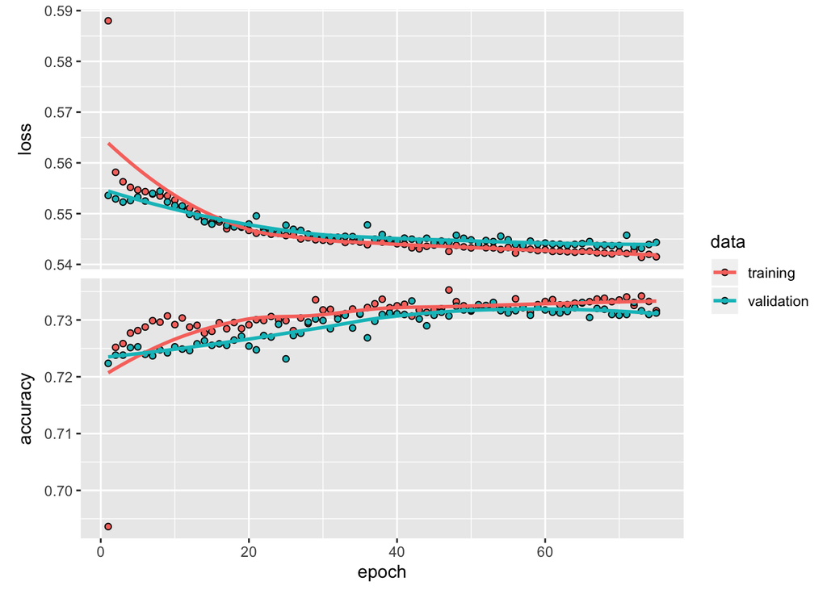

```r
plot(ann2_model)
```

###### Predictions of ANN2

Predicting the output class and class probability of validation data using ANN2.

```r
#predicted class
yhat_keras_class_vec <- predict_classes(object = keras_model2, x = as.matrix(x_sval2)) %>%
  as.vector()

#predicted class probability
yhat_keras_prob_vec  <- predict_proba(object = keras_model2, x = as.matrix(x_sval2)) %>%
    as.vector()
```

Creating a data frame with actual value, estimated value and probability of the validation data.

```r
estimates_ann2 <- tibble(truth = as.factor(y_sval2),
                              estimate = as.factor(yhat_keras_class_vec),
                              class_prob = yhat_keras_prob_vec)

options(yardstick.event_first = FALSE)
```

Obtaining confusion table for validation data to examine the performance.

```r
estimates_ann2 %>% conf_mat(truth, estimate)
```

```
##           Truth
## Prediction    0    1
##          0 3629 1487
##          1  998 3326
```

Determining accuracy of validation dataset.

```r
estimates_ann2 %>% metrics(truth, estimate)
```

```
## # A tibble: 2 x 3
##   .metric  .estimator .estimate
##   <chr>    <chr>          <dbl>
## 1 accuracy binary         0.737
## 2 kap      binary         0.474
```

ANN2 correctly predicts the class 73% of the time.

AUC score of ANN2.

```r
estimates_ann2 %>% roc_auc(truth, class_prob)
```

```
## # A tibble: 1 x 3
##   .metric .estimator .estimate
##   <chr>   <chr>          <dbl>
## 1 roc_auc binary         0.803
```

#### Best performing models

| Model | Hyper-parameters |
| --- | --- |
| LR | - |
| DT | minsplit = 40, minbucket = 10, maxdepth = 30 |
| ANN0 | output layer: optimizer = “adam”, loss = “binary_crossentropy” |
|  | batch_size = 60, epochs = 75 |
| ANN1 | hidden layer 1: units = 50, activation = “relu”, dropout rate = 0.1 |
|  | output layer: optimizer = “adam”, loss = “binary_crossentropy” |
|  | batch_size = 50, epochs = 75 |
| ANN2 | hidden layer 1: units = 50, activation = “sigmoid”, dropout rate = 0.1 |
|  | hidden layer 2: units = 35, activation = “tanh”, dropout rate = 0.1 |
|  | output layer: optimizer = “adam”, loss = “binary_crossentropy” |
|  | batch_size = 50, epochs = 75 |

#### Model performance evaluation methods

- The above models are evaulated based on accuracy and AUC score.
- In order to produce unbiased and low variance estimates, performance of the models can be determined by using hold out methods like creating a confusion matrix for the validation data.
- The advantage of ROC curve and AUC score is that it is independent of the change in proportion of data points.
- Another measure that could be used is time complexity.

#### Comparing Linear SVM, Logistic Regression, and Single Layer Perceptron

Both single layer perceptron and linear SVM cannot fully separate problems that are not linearly separable.

SVM tries to finds the best margin that separates the classes and this reduces the risk of error on the data, while logistic regression does not, instead it can have different decision boundaries with different weights that are near the optimal point.

The risk of overfitting is less in SVM, while logistic regression is vulnerable to overfitting.

Logistic regression and linear SVM can be used when we have fewer features and large number of observations. Both have similar performance but depending on your features, one may be more efficient than the other.

Logistic regression and single layer perceptron are similar to each other. In logistic regression weights are assigned to each feature to determine the class of target variable. It is a linear method, but are transformed using the logistic function.

In case of single layer perceptron input layer is directly fed to the output layer with weights and activation function which is sigmoid in case of binary classification. The sigmoid fucntion works similar to the logistic function.

Logistic regression, linear SVM and single layer perceptron work well with linearly separable problem.

## Section 3: Combination and Comparison of Multiple Machine Learning Algorithms

Comparing the decision tree model trained above with other models.

Best performing decision tree model.

```r
dt_model$finalModel
```

```
## n= 37762
##
## node), split, n, loss, yval, (yprob)
##       * denotes terminal node
##
##   1) root 37762 18508 1 (0.4901223 0.5098777)
##     2) High.Blood.Pressure< 129.5 21788  7071 0 (0.6754636 0.3245364)
##       4) Age< 54.5 13464  3294 0 (0.7553476 0.2446524)
##         8) Cholesteroltoo high< 0.5 12886  2961 0 (0.7702157 0.2297843) *
##         9) Cholesteroltoo high>=0.5 578   245 1 (0.4238754 0.5761246)
##          18) Glucosetoo high>=0.5 344   153 0 (0.5552326 0.4447674) *
##          19) Glucosetoo high< 0.5 234    54 1 (0.2307692 0.7692308) *
##       5) Age>=54.5 8324  3777 0 (0.5462518 0.4537482)
##        10) Cholesteroltoo high< 0.5 7432  3143 0 (0.5770990 0.4229010)
##          20) Age< 60.5 5401  2095 0 (0.6121089 0.3878911) *
##          21) Age>=60.5 2031   983 1 (0.4839980 0.5160020)
##            42) Exercise>=0.5 1588   775 0 (0.5119647 0.4880353)
##              84) Weight< 53.5 84    25 0 (0.7023810 0.2976190) *
##              85) Weight>=53.5 1504   750 0 (0.5013298 0.4986702)
##               170) Height>=170.5 282   116 0 (0.5886525 0.4113475) *
##               171) Height< 170.5 1222   588 1 (0.4811784 0.5188216) *
##            43) Exercise< 0.5 443   170 1 (0.3837472 0.6162528) *
##        11) Cholesteroltoo high>=0.5 892   258 1 (0.2892377 0.7107623) *
##     3) High.Blood.Pressure>=129.5 15974  3791 1 (0.2373232 0.7626768) *
```

#### Model performance table

[output not shown]

## Section 4: Prediction and interpretation

#### Reading the testing data from csv file

```r
disease_test <- read_csv("Disease Prediction Testing(2).csv", col_types = cols())
```

#### Preprocessing testing data

##### Valid column names

```r
colnames(disease_test) <- make.names(colnames(disease_test))
```

##### Data outliers

Winsorizing extreme outliers in High Blood Pressure, Low Blood Pressure, Height and Weight similar to training data.

```r
winsorize <- function(x){
   qnt <- quantile(x, probs = c(.25, .75), na.rm = T)
   caps <- quantile(x, probs = c(.05, .95), na.rm = T)
   bound <- 1.5 * IQR(x, na.rm = T)
   if((x == disease_test$Height) | (x == disease_test$Weight)){
     x[x < (qnt[1] - bound)] <- caps[1]
   }
   else{
     x[x < (qnt[1] - bound)] <- caps[1]
     x[x > (qnt[2] + bound)] <- caps[2]
   }
   return(x)
}

disease_test$High.Blood.Pressure <- winsorize(disease_test$High.Blood.Pressure)
disease_test$Low.Blood.Pressure <- winsorize(disease_test$Low.Blood.Pressure)
disease_test$Height <- winsorize(disease_test$Height)
disease_test$Weight <- winsorize(disease_test$Weight)
```

##### Erroneous data

```r
nrow(disease_test[disease_test$High.Blood.Pressure < disease_test$Low.Blood.Pressure,])
```

```
## [1] 9
```

Swapping values where High Blood Pressure is lower than Low Blood Pressure.

```r
index <- which(disease_test$High.Blood.Pressure < disease_test$Low.Blood.Pressure)
for(i in index){
  x <- disease_test[i, "High.Blood.Pressure"]
  disease_test[i, "High.Blood.Pressure"] <- disease_test[i, "Low.Blood.Pressure"]
  disease_test[i, "Low.Blood.Pressure"] <- x
}
```

##### Numerization and standardization using recipes

```r
rec_obj <- recipe(ID ~ ., data = disease_test) %>%
  step_dummy(all_nominal(), -all_outcomes()) %>%
  step_center(all_predictors(), -all_outcomes()) %>%
  step_scale(all_predictors(), -all_outcomes()) %>%
  prep(data = disease_test)
```

Applying the above recipe on testing data to convert it to dataset required for ANN.

```r
x_test <- bake(rec_obj, new_data = disease_test) %>% select(-ID)
```

#### Prediction using Logistic Regression

```r
lr_pred <- predict(lr_model, newdata = disease_test)
```

#### Prediction using ANN

```r
ann0_pred <- predict_classes(object = keras_model0, x = as.matrix(x_test)) %>%
  as.vector()

ann1_pred <- predict_classes(object = keras_model1, x = as.matrix(x_test)) %>%
  as.vector()

ann2_pred <- predict_classes(object = keras_model2, x = as.matrix(x_test)) %>%
  as.vector()
```

#### Prediction using Decision Tree

```r
dt_pred <- predict(dt_model, newdata = disease_test)
```

#### Combining the predictions made by all five models

```r
prediction <- data.frame(ID = disease_test$ID)
prediction$DT <- dt_pred
prediction$LR <- lr_pred
prediction$ANN0 <- ann0_pred
prediction$ANN1 <- ann1_pred
prediction$ANN2 <- ann2_pred
```

#### Writing prediction results to csv file

```r
write.csv(prediction, "prediction.csv")
```